# CMP330 Data Analytics - Assessment 2 (Pre-Assignment)

# Part 2a: Building the Models

### Decision Tree (C5.0)

```r
library(caret)
library(C50)

cart_fit  <- C5.0(part_train[-7], part_train$acceptability)
cart_pred <- predict(cart_fit, part_test)
confusionMatrix(cart_pred, part_test$acceptability)
```

```
Confusion Matrix and Statistics

          Reference
Prediction unacc acc good vgood
     unacc   136   1    0     0
     acc       3  43    1     0
     good      0   2    7     0
     vgood     0   0    0     7

Overall Statistics

               Accuracy : 0.965
                 95% CI : (0.9292, 0.9858)
    No Information Rate : 0.695
    P-Value [Acc > NIR] : < 2.2e-16

                  Kappa : 0.925

 Mcnemar's Test P-Value : NA

Statistics by Class:

                     Class: unacc Class: acc Class: good
Sensitivity                0.9784     0.9348      0.8750
Specificity                0.9836     0.9740      0.9896
Pos Pred Value             0.9927     0.9149      0.7778
Neg Pred Value             0.9524     0.9804      0.9948
Prevalence                 0.6950     0.2300      0.0400
Detection Rate             0.6800     0.2150      0.0350
Detection Prevalence       0.6850     0.2350      0.0450
Balanced Accuracy          0.9810     0.9544      0.9323
                     Class: vgood
Sensitivity                 1.000
Specificity                 1.000
Pos Pred Value              1.000
Neg Pred Value              1.000
Prevalence                  0.035
Detection Rate              0.035
Detection Prevalence        0.035
Balanced Accuracy           1.000
```

### Naive Bayes

```r
library(e1071)
set.seed(123)

bayes_fit  <- naiveBayes(part_train[, -7], part_train$acceptability)
bayes_pred <- predict(bayes_fit, part_test)
confusionMatrix(bayes_pred, part_test$acceptability)
```

```
Confusion Matrix and Statistics

          Reference
Prediction unacc acc good vgood
     unacc   130  12    1     0
     acc       9  33    2     4
     good      0   1    5     1
     vgood     0   0    0     2

Overall Statistics

               Accuracy : 0.85
                 95% CI : (0.7928, 0.8965)
    No Information Rate : 0.695
    P-Value [Acc > NIR] : 3.117e-07

                  Kappa : 0.6638

 Mcnemar's Test P-Value : NA

Statistics by Class:

                     Class: unacc Class: acc Class: good
Sensitivity                0.9353     0.7174      0.6250
Specificity                0.7869     0.9026      0.9896
Pos Pred Value             0.9091     0.6875      0.7143
Neg Pred Value             0.8421     0.9145      0.9845
Prevalence                 0.6950     0.2300      0.0400
Detection Rate             0.6500     0.1650      0.0250
Detection Prevalence       0.7150     0.2400      0.0350
Balanced Accuracy          0.8611     0.8100      0.8073
                     Class: vgood
Sensitivity                0.2857
Specificity                1.0000
Pos Pred Value             1.0000
Neg Pred Value             0.9747
Prevalence                 0.0350
Detection Rate             0.0100
Detection Prevalence       0.0100
Balanced Accuracy          0.6429
```

### Multinomial Logistic Regression

```r
library(nnet)

logit_fit  <- multinom(acceptability ~ ., data = part_train)
logit_pred <- predict(logit_fit, part_test)
confusionMatrix(logit_pred, part_test$acceptability)
```

```
Confusion Matrix and Statistics

          Reference
Prediction unacc acc good vgood
     unacc   131   1    0     0
     acc       8  44    2     0
     good      0   1    6     1
     vgood     0   0    0     6

Overall Statistics

               Accuracy : 0.935
                 95% CI : (0.8914, 0.9649)
    No Information Rate : 0.695
    P-Value [Acc > NIR] : < 2.2e-16

                  Kappa : 0.8636

 Mcnemar's Test P-Value : NA

Statistics by Class:

                     Class: unacc Class: acc Class: good
Sensitivity                0.9424     0.9565      0.7500
Specificity                0.9836     0.9351      0.9896
Pos Pred Value             0.9924     0.8148      0.7500
Neg Pred Value             0.8824     0.9863      0.9896
Prevalence                 0.6950     0.2300      0.0400
Detection Rate             0.6550     0.2200      0.0300
Detection Prevalence       0.6600     0.2700      0.0400
Balanced Accuracy          0.9630     0.9458      0.8698
                     Class: vgood
Sensitivity                0.8571
Specificity                1.0000
Pos Pred Value             1.0000
Neg Pred Value             0.9948
Prevalence                 0.0350
Detection Rate             0.0300
Detection Prevalence       0.0300
Balanced Accuracy          0.9286
```

### SVM

```r
library(kernlab)

# linear kernel first
svmLin_fit  <- ksvm(acceptability ~ ., data = part_train, kernel = "vanilladot")
svmLin_pred <- predict(svmLin_fit, part_test)
confusionMatrix(svmLin_pred, part_test$acceptability)
```

```
Confusion Matrix and Statistics

          Reference
Prediction unacc acc good vgood
     unacc   133   5    0     0
     acc       6  41    2     0
     good      0   0    6     0
     vgood     0   0    0     7

Overall Statistics

               Accuracy : 0.935
                 95% CI : (0.8914, 0.9649)
    No Information Rate : 0.695
    P-Value [Acc > NIR] : < 2.2e-16

                  Kappa : 0.8592

 Mcnemar's Test P-Value : NA

Statistics by Class:

                     Class: unacc Class: acc Class: good
Sensitivity                0.9568     0.8913      0.7500
Specificity                0.9180     0.9481      1.0000
Pos Pred Value             0.9638     0.8367      1.0000
Neg Pred Value             0.9032     0.9669      0.9897
Prevalence                 0.6950     0.2300      0.0400
Detection Rate             0.6650     0.2050      0.0300
Detection Prevalence       0.6900     0.2450      0.0300
Balanced Accuracy          0.9374     0.9197      0.8750
                     Class: vgood
Sensitivity                 1.000
Specificity                 1.000
Pos Pred Value              1.000
Neg Pred Value              1.000
Prevalence                  0.035
Detection Rate              0.035
Detection Prevalence        0.035
Balanced Accuracy           1.000
```

```r
# and the e1071 default (radial kernel) for comparison - curious if the
# non-linear boundary does any better here
svmRad_fit  <- svm(acceptability ~ ., data = part_train)
svmRad_pred <- predict(svmRad_fit, part_test)
confusionMatrix(svmRad_pred, part_test$acceptability)
```

```
Confusion Matrix and Statistics

          Reference
Prediction unacc acc good vgood
     unacc   130   0    0     0
     acc       9  46    8     7
     good      0   0    0     0
     vgood     0   0    0     0

Overall Statistics

               Accuracy : 0.88
                 95% CI : (0.8267, 0.9216)
    No Information Rate : 0.695
    P-Value [Acc > NIR] : 5.983e-10

                  Kappa : 0.7435

 Mcnemar's Test P-Value : NA

Statistics by Class:

                     Class: unacc Class: acc Class: good
Sensitivity                0.9353     1.0000        0.00
Specificity                1.0000     0.8442        1.00
Pos Pred Value             1.0000     0.6571         NaN
Neg Pred Value             0.8714     1.0000        0.96
Prevalence                 0.6950     0.2300        0.04
Detection Rate             0.6500     0.2300        0.00
Detection Prevalence       0.6500     0.3500        0.00
Balanced Accuracy          0.9676     0.9221        0.50
                     Class: vgood
Sensitivity                 0.000
Specificity                 1.000
Pos Pred Value                NaN
Neg Pred Value              0.965
Prevalence                  0.035
Detection Rate              0.000
Detection Prevalence        0.000
Balanced Accuracy           0.500
```

### Neural Network

```r
# following the nnet approach from GeeksforGeeks:
# https://www.geeksforgeeks.org/r-language/neural-networks-using-the-r-nnet-package/
mlp_fit  <- nnet(acceptability ~ ., data = part_train, size = 5)
mlp_pred <- predict(mlp_fit, part_test, type = "class")
confusionMatrix(factor(mlp_pred), part_test$acceptability)
```

```
Confusion Matrix and Statistics

          Reference
Prediction unacc acc good vgood
     unacc   138   4    0     0
     acc       1  40    1     1
     good      0   1    6     0
     vgood     0   1    1     6

Overall Statistics

               Accuracy : 0.95
                 95% CI : (0.91, 0.9758)
    No Information Rate : 0.695
    P-Value [Acc > NIR] : < 2.2e-16

                  Kappa : 0.8899

 Mcnemar's Test P-Value : NA

Statistics by Class:

                     Class: unacc Class: acc Class: good
Sensitivity                0.9928     0.8696      0.7500
Specificity                0.9344     0.9805      0.9948
Pos Pred Value             0.9718     0.9302      0.8571
Neg Pred Value             0.9828     0.9618      0.9896
Prevalence                 0.6950     0.2300      0.0400
Detection Rate             0.6900     0.2000      0.0300
Detection Prevalence       0.7100     0.2150      0.0350
Balanced Accuracy          0.9636     0.9250      0.8724
                     Class: vgood
Sensitivity                0.8571
Specificity                0.9896
Pos Pred Value             0.7500
Neg Pred Value             0.9948
Prevalence                 0.0350
Detection Rate             0.0300
Detection Prevalence       0.0400
Balanced Accuracy          0.9234
```

## Cross-validated versions

Same five algorithms, but this time letting `caret::train()` handle 10-fold CV so the accuracy estimate isn’t just dependent on one lucky/unlucky split.

### Decision Tree - CV

```r
cv_setup <- trainControl(method = "cv", number = 10)
set.seed(123)

cart_cv_fit  <- train(part_train[, -7], part_train[, 7], method = "C5.0", trControl = cv_setup)
cart_cv_fit
```

```
C5.0

800 samples
  6 predictor
  4 classes: 'unacc', 'acc', 'good', 'vgood'

No pre-processing
Resampling: Cross-Validated (10 fold)
Summary of sample sizes: 720, 720, 720, 719, 719, 721, ...
Resampling results across tuning parameters:

  model  winnow  trials  Accuracy   Kappa
  rules  FALSE    1      0.9399652  0.8707076
  rules  FALSE   10      0.9649193  0.9239429
  rules  FALSE   20      0.9674039  0.9293780
  rules   TRUE    1      0.9374807  0.8657737
  rules   TRUE   10      0.9537619  0.9010344
  rules   TRUE   20      0.9574965  0.9090808
  tree   FALSE    1      0.9399648  0.8709073
  tree   FALSE   10      0.9561844  0.9056297
  tree   FALSE   20      0.9599660  0.9146660
  tree    TRUE    1      0.9387148  0.8685632
  tree    TRUE   10      0.9437615  0.8799486
  tree    TRUE   20      0.9475586  0.8884975

Accuracy was used to select the optimal model using
 the largest value.
The final values used for the model were trials = 20, model
 = rules and winnow = FALSE.
```

```r
cart_cv_pred <- predict(cart_cv_fit, part_test)
confusionMatrix(cart_cv_pred, part_test$acceptability)
```

```
Confusion Matrix and Statistics

          Reference
Prediction unacc acc good vgood
     unacc   139   0    0     0
     acc       0  45    1     0
     good      0   1    7     0
     vgood     0   0    0     7

Overall Statistics

               Accuracy : 0.99
                 95% CI : (0.9643, 0.9988)
    No Information Rate : 0.695
    P-Value [Acc > NIR] : < 2.2e-16

                  Kappa : 0.9783

 Mcnemar's Test P-Value : NA

Statistics by Class:

                     Class: unacc Class: acc Class: good
Sensitivity                 1.000     0.9783      0.8750
Specificity                 1.000     0.9935      0.9948
Pos Pred Value              1.000     0.9783      0.8750
Neg Pred Value              1.000     0.9935      0.9948
Prevalence                  0.695     0.2300      0.0400
Detection Rate              0.695     0.2250      0.0350
Detection Prevalence        0.695     0.2300      0.0400
Balanced Accuracy           1.000     0.9859      0.9349
                     Class: vgood
Sensitivity                 1.000
Specificity                 1.000
Pos Pred Value              1.000
Neg Pred Value              1.000
Prevalence                  0.035
Detection Rate              0.035
Detection Prevalence        0.035
Balanced Accuracy           1.000
```

### Naive Bayes - CV

```r
cv_setup <- trainControl(method = "cv", number = 10)
set.seed(123)

bayes_cv_fit  <- train(part_train[, -7], part_train[, 7], method = "nb", trControl = cv_setup)
bayes_cv_fit
```

```
Naive Bayes

800 samples
  6 predictor
  4 classes: 'unacc', 'acc', 'good', 'vgood'

No pre-processing
Resampling: Cross-Validated (10 fold)
Summary of sample sizes: 720, 720, 720, 719, 719, 721, ...
Resampling results across tuning parameters:

  usekernel  Accuracy   Kappa
  FALSE      0.8362418  0.6274638
   TRUE      0.8362418  0.6274638

Tuning parameter 'fL' was held constant at a value of
 0
Tuning parameter 'adjust' was held constant at a value of 1
Accuracy was used to select the optimal model using
 the largest value.
The final values used for the model were fL = 0, usekernel
 = FALSE and adjust = 1.
```

```r
bayes_cv_pred <- predict(bayes_cv_fit, part_test)
confusionMatrix(bayes_cv_pred, part_test$acceptability)
```

```
Confusion Matrix and Statistics

          Reference
Prediction unacc acc good vgood
     unacc   130  12    1     0
     acc       9  33    2     4
     good      0   1    5     1
     vgood     0   0    0     2

Overall Statistics

               Accuracy : 0.85
                 95% CI : (0.7928, 0.8965)
    No Information Rate : 0.695
    P-Value [Acc > NIR] : 3.117e-07

                  Kappa : 0.6638

 Mcnemar's Test P-Value : NA

Statistics by Class:

                     Class: unacc Class: acc Class: good
Sensitivity                0.9353     0.7174      0.6250
Specificity                0.7869     0.9026      0.9896
Pos Pred Value             0.9091     0.6875      0.7143
Neg Pred Value             0.8421     0.9145      0.9845
Prevalence                 0.6950     0.2300      0.0400
Detection Rate             0.6500     0.1650      0.0250
Detection Prevalence       0.7150     0.2400      0.0350
Balanced Accuracy          0.8611     0.8100      0.8073
                     Class: vgood
Sensitivity                0.2857
Specificity                1.0000
Pos Pred Value             1.0000
Neg Pred Value             0.9747
Prevalence                 0.0350
Detection Rate             0.0100
Detection Prevalence       0.0100
Balanced Accuracy          0.6429
```

### Logistic Regression - CV

```r
cv_setup <- trainControl(method = "cv", number = 10)
set.seed(123)

logit_cv_fit  <- train(part_train[, -7], part_train[, 7], method = "multinom",
                        trControl = cv_setup, trace = FALSE)
logit_cv_fit
```

```
Penalized Multinomial Regression

800 samples
  6 predictor
  4 classes: 'unacc', 'acc', 'good', 'vgood'

No pre-processing
Resampling: Cross-Validated (10 fold)
Summary of sample sizes: 720, 720, 720, 719, 719, 721, ...
Resampling results across tuning parameters:

  decay  Accuracy   Kappa
  0e+00  0.9249795  0.8394418
  1e-04  0.9249945  0.8396601
  1e-01  0.8813684  0.7413285

Accuracy was used to select the optimal model using
 the largest value.
The final value used for the model was decay = 1e-04.
```

```r
logit_cv_pred <- predict(logit_cv_fit, part_test)
confusionMatrix(logit_cv_pred, part_test$acceptability)
```

```
Confusion Matrix and Statistics

          Reference
Prediction unacc acc good vgood
     unacc   131   1    0     0
     acc       8  43    2     0
     good      0   1    6     1
     vgood     0   1    0     6

Overall Statistics

               Accuracy : 0.93
                 95% CI : (0.8853, 0.9612)
    No Information Rate : 0.695
    P-Value [Acc > NIR] : 3.476e-16

                  Kappa : 0.8534

 Mcnemar's Test P-Value : NA

Statistics by Class:

                     Class: unacc Class: acc Class: good
Sensitivity                0.9424     0.9348      0.7500
Specificity                0.9836     0.9351      0.9896
Pos Pred Value             0.9924     0.8113      0.7500
Neg Pred Value             0.8824     0.9796      0.9896
Prevalence                 0.6950     0.2300      0.0400
Detection Rate             0.6550     0.2150      0.0300
Detection Prevalence       0.6600     0.2650      0.0400
Balanced Accuracy          0.9630     0.9349      0.8698
                     Class: vgood
Sensitivity                0.8571
Specificity                0.9948
Pos Pred Value             0.8571
Neg Pred Value             0.9948
Prevalence                 0.0350
Detection Rate             0.0300
Detection Prevalence       0.0350
Balanced Accuracy          0.9260
```

### Neural Network - CV

```r
cv_setup <- trainControl(method = "cv", number = 10)
set.seed(123)

mlp_cv_fit  <- train(part_train[, -7], part_train[, 7], method = "nnet",
                      trControl = cv_setup, trace = FALSE)
mlp_cv_fit
```

```
Neural Network

800 samples
  6 predictor
  4 classes: 'unacc', 'acc', 'good', 'vgood'

No pre-processing
Resampling: Cross-Validated (10 fold)
Summary of sample sizes: 720, 720, 720, 719, 719, 721, ...
Resampling results across tuning parameters:

  size  decay  Accuracy   Kappa
  1     0e+00  0.9149008  0.8171319
  1     1e-04  0.9112920  0.8099249
  1     1e-01  0.8825084  0.7379648
  3     0e+00  0.9376053  0.8674752
  3     1e-04  0.9275416  0.8424557
  3     1e-01  0.9449340  0.8820046
  5     0e+00  0.9475582  0.8892958
  5     1e-04  0.9463399  0.8868588
  5     1e-01  0.9550594  0.9042634

Accuracy was used to select the optimal model using
 the largest value.
The final values used for the model were size = 5 and decay
 = 0.1.
```

```r
mlp_cv_pred <- predict(mlp_cv_fit, part_test)
confusionMatrix(mlp_cv_pred, part_test$acceptability)
```

```
Confusion Matrix and Statistics

          Reference
Prediction unacc acc good vgood
     unacc   139   1    0     0
     acc       0  44    1     0
     good      0   0    7     1
     vgood     0   1    0     6

Overall Statistics

               Accuracy : 0.98
                 95% CI : (0.9496, 0.9945)
    No Information Rate : 0.695
    P-Value [Acc > NIR] : < 2.2e-16

                  Kappa : 0.9564

 Mcnemar's Test P-Value : NA

Statistics by Class:

                     Class: unacc Class: acc Class: good
Sensitivity                1.0000     0.9565      0.8750
Specificity                0.9836     0.9935      0.9948
Pos Pred Value             0.9929     0.9778      0.8750
Neg Pred Value             1.0000     0.9871      0.9948
Prevalence                 0.6950     0.2300      0.0400
Detection Rate             0.6950     0.2200      0.0350
Detection Prevalence       0.7000     0.2250      0.0400
Balanced Accuracy          0.9918     0.9750      0.9349
                     Class: vgood
Sensitivity                0.8571
Specificity                0.9948
Pos Pred Value             0.8571
Neg Pred Value             0.9948
Prevalence                 0.0350
Detection Rate             0.0300
Detection Prevalence       0.0350
Balanced Accuracy          0.9260
```

### SVM - CV

```r
set.seed(123)
svm_cv_fit  <- ksvm(acceptability ~ ., data = part_train, kernel = "vanilladot", cross = 10)
svm_cv_fit
```

```
Support Vector Machine object of class "ksvm"

SV type: C-svc  (classification)
 parameter : cost C = 1

Linear (vanilla) kernel function.

Number of Support Vectors : 293

Objective Function Value : -137.875 -20 -11.7143 -40.9483 -17.3171 -14
Training error : 0.0725
Cross validation error : 0.0975
```

```r
svm_cv_pred <- predict(svm_cv_fit, part_test)
confusionMatrix(svm_cv_pred, part_test$acceptability)
```

```
Confusion Matrix and Statistics

          Reference
Prediction unacc acc good vgood
     unacc   133   5    0     0
     acc       6  41    2     0
     good      0   0    6     0
     vgood     0   0    0     7

Overall Statistics

               Accuracy : 0.935
                 95% CI : (0.8914, 0.9649)
    No Information Rate : 0.695
    P-Value [Acc > NIR] : < 2.2e-16

                  Kappa : 0.8592

 Mcnemar's Test P-Value : NA

Statistics by Class:

                     Class: unacc Class: acc Class: good
Sensitivity                0.9568     0.8913      0.7500
Specificity                0.9180     0.9481      1.0000
Pos Pred Value             0.9638     0.8367      1.0000
Neg Pred Value             0.9032     0.9669      0.9897
Prevalence                 0.6950     0.2300      0.0400
Detection Rate             0.6650     0.2050      0.0300
Detection Prevalence       0.6900     0.2450      0.0300
Balanced Accuracy          0.9374     0.9197      0.8750
                     Class: vgood
Sensitivity                 1.000
Specificity                 1.000
Pos Pred Value              1.000
Neg Pred Value              1.000
Prevalence                  0.035
Detection Rate              0.035
Detection Prevalence        0.035
Balanced Accuracy           1.000
```

## Feature selection - trying a few different values of x

Rather than just picking the top 3 features and stopping there, I ranked all six by their mutual information with the target and then looped through the top 2, top 3, top 4 and top 5 to see where accuracy actually levels off. Decision tree is used as the test algorithm here since it trains quickly.

```r
mi_train <- mutinformation(part_train)
ranked_features <- names(sort(mi_train[7, -7], decreasing = TRUE))
ranked_features  # feature names, best predictor first
```

```
[1] "safety"   "persons"  "buying"   "maint"    "lug_boot"
[6] "doors"
```

```r
# loop over a few candidate values of x and record accuracy for each
feature_counts <- c(2, 3, 4, 5)
fs_results <- data.frame(top_x = integer(), accuracy = numeric())

for (x in feature_counts) {
  chosen_cols <- ranked_features[1:x]

  fs_fit  <- C5.0(part_train[, chosen_cols], part_train$acceptability)
  fs_pred <- predict(fs_fit, part_test)
  acc <- confusionMatrix(fs_pred, part_test$acceptability)$overall["Accuracy"]

  fs_results <- rbind(fs_results, data.frame(top_x = x, accuracy = acc))
}

fs_results
```

|  | top_x | accuracy |
| --- | --- | --- |
| Accuracy | 2 | 0.800 |
| Accuracy1 | 3 | 0.820 |
| Accuracy2 | 4 | 0.885 |
| Accuracy3 | 5 | 0.930 |

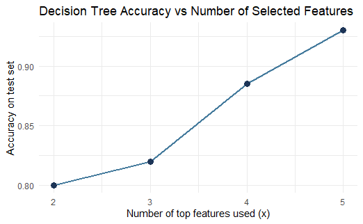

```r
# quick plot so it's obvious where extra features stop helping
ggplot(fs_results, aes(x = top_x, y = accuracy)) +
  geom_line(color = "#457B9D", linewidth = 1) +
  geom_point(color = "#1D3557", size = 3) +
  labs(title = "Decision Tree Accuracy vs Number of Selected Features",
       x = "Number of top features used (x)", y = "Accuracy on test set") +
  theme_minimal()
```

Repeating the same idea with Naive Bayes and multinomial logistic regression, just using top 3 as a representative case (matching what the brief’s example used) rather than re-running the full loop for every algorithm:

```r
top3_cols <- ranked_features[1:3]

bayes_fs_fit  <- naiveBayes(part_train[, top3_cols], part_train$acceptability)
bayes_fs_pred <- predict(bayes_fs_fit, part_test)
confusionMatrix(bayes_fs_pred, part_test$acceptability)
```

```
Confusion Matrix and Statistics

          Reference
Prediction unacc acc good vgood
     unacc   129  14    3     0
     acc      10  32    5     7
     good      0   0    0     0
     vgood     0   0    0     0

Overall Statistics

               Accuracy : 0.805
                 95% CI : (0.7432, 0.8575)
    No Information Rate : 0.695
    P-Value [Acc > NIR] : 0.0003038

                  Kappa : 0.5471

 Mcnemar's Test P-Value : NA

Statistics by Class:

                     Class: unacc Class: acc Class: good
Sensitivity                0.9281     0.6957        0.00
Specificity                0.7213     0.8571        1.00
Pos Pred Value             0.8836     0.5926         NaN
Neg Pred Value             0.8148     0.9041        0.96
Prevalence                 0.6950     0.2300        0.04
Detection Rate             0.6450     0.1600        0.00
Detection Prevalence       0.7300     0.2700        0.00
Balanced Accuracy          0.8247     0.7764        0.50
                     Class: vgood
Sensitivity                 0.000
Specificity                 1.000
Pos Pred Value                NaN
Neg Pred Value              0.965
Prevalence                  0.035
Detection Rate              0.000
Detection Prevalence        0.000
Balanced Accuracy           0.500
```

```r
# multinom needs a formula, so I build one dynamically from the chosen columns
fs_formula <- as.formula(paste("acceptability ~", paste(top3_cols, collapse = " + ")))
logit_fs_fit  <- multinom(fs_formula, data = part_train)
logit_fs_pred <- predict(logit_fs_fit, part_test)
confusionMatrix(logit_fs_pred, part_test$acceptability)
```

```
Confusion Matrix and Statistics

          Reference
Prediction unacc acc good vgood
     unacc   127   9    0     0
     acc      12  34    8     5
     good      0   0    0     0
     vgood     0   3    0     2

Overall Statistics

               Accuracy : 0.815
                 95% CI : (0.7541, 0.8663)
    No Information Rate : 0.695
    P-Value [Acc > NIR] : 8.287e-05

                  Kappa : 0.5967

 Mcnemar's Test P-Value : NA

Statistics by Class:

                     Class: unacc Class: acc Class: good
Sensitivity                0.9137     0.7391        0.00
Specificity                0.8525     0.8377        1.00
Pos Pred Value             0.9338     0.5763         NaN
Neg Pred Value             0.8125     0.9149        0.96
Prevalence                 0.6950     0.2300        0.04
Detection Rate             0.6350     0.1700        0.00
Detection Prevalence       0.6800     0.2950        0.00
Balanced Accuracy          0.8831     0.7884        0.50
                     Class: vgood
Sensitivity                0.2857
Specificity                0.9845
Pos Pred Value             0.4000
Neg Pred Value             0.9744
Prevalence                 0.0350
Detection Rate             0.0100
Detection Prevalence       0.0250
Balanced Accuracy          0.6351
```

# Part 2b: Hyperparameter Tuning

## Neural network - decay

I used a wider spread of decay values than a simple 0-to-0.1 sweep, including a couple of larger values, to check whether accuracy keeps improving or starts dropping again once regularisation gets too strong.

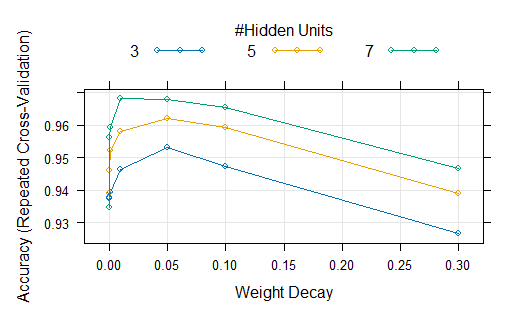

```r
tune_setup <- trainControl(method = "repeatedcv", number = 10, repeats = 10)
mlp_grid <- expand.grid(size = c(3, 5, 7),
                         decay = c(0, 0.0005, 0.001, 0.01, 0.05, 0.1, 0.3))
set.seed(123)

mlp_tuned <- train(part_train[, -7], part_train[, 7], method = "nnet",
                    trControl = tune_setup, tuneGrid = mlp_grid, trace = FALSE)
plot(mlp_tuned)
```

## Decision tree - trials

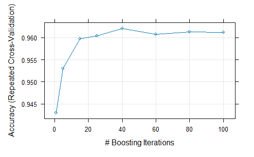

```r
tune_setup <- trainControl(method = "repeatedcv", number = 10, repeats = 10)
cart_grid <- expand.grid(model = "tree",
                          trials = c(1, 5, 15, 25, 40, 60, 80, 100),
                          winnow = FALSE)
set.seed(123)

cart_tuned <- train(part_train[, -7], part_train[, 7], method = "C5.0",
                     trControl = tune_setup, tuneGrid = cart_grid)
plot(cart_tuned)
```

# Part 3. Presentation of Specified Results

*(To be finalised in the lab session once the exact figures required are confirmed - the feature-selection accuracy-vs-x plot above and the two tuning plots are strong candidates to include here.)*